# Vocabulary Complexity Analysis on Inaugural Speeches

# Introduction

During the 2016 presidential campaign, Donald J. Trump became the most controversial figure of the year due to the simplicity of his language and outspoken character. In this project, I seek to answer the following questions: (1) Does Donald Trump really speak in a simpler way than other politicians? (2) If he does, is Trump an outlier or is it the outcome of some underlying trend? To answer these questions, I choose inaugural speeches as the objects of our analysis. Presidential inauguration speeches are of great importance in that they sets the tones of the political sphere in the next four years while inspiring people to move forward under new leadership. Therefore I believe that it can objectively reflect the presidents language usage. First, I measure the readibilty of inaugural speech by gauging the complexity of vocabulary and comparing Donald Trump’s vocabulary level exhibited in his inaugural speech to those of other four influential presidents.

# Data Construction

Before showing the result of my anlaysis, I will briefly talk about my data. I scrap data from online vocabulary list which consists of [Tier II](https://www.quora.com/What-exactly-is-Tier-2-vocabulary-according-to-the-Common-Core-State-Standards-CCSS) vocabulary from grade zero (kindergarten) to grade twelve. Next, from the “speech.list” data constructed in “Tutorial-TextMining”, I split sentences into individual terms and then try to match these terms in each line with vocabulary in the thirteen tier II lists. In this way, I am able to calculate the number of words from each level (grade) within each sentence.

```r
head(sentdata[,c(1,10,23:35)])
```

[output not shown]

# Comparing Trump with other presidents

[figure not shown]

[figure not shown]

[figure not shown]

```r
DT <- agg_stack[(agg_stack$Group.1=="Donald J. Trump"),]
BO <- agg_stack[(agg_stack$Group.1=="George W. Bush"),]
combdata <- rbind(DT,BO)
combdata[,2:14]<-combdata[,2:14]/combdata[,15]
comb <-reshape(combdata[,1:14],varying = c("zero","one","two","three","four","five","six","seven","eight","nine","ten","eleven","twelve"),v.names = "level",direction = "long")
p3 <- ggplot(comb, aes( time, level))
p3 + geom_area(aes(colour = Group.1, fill= Group.1,alpha=0.01), position = 'identity')+xlab("vocabulary level")+ylab("percentage")
```

# Is party a deciding factor?

Can Trump’s speaking manner (a great volume of basic terms) be explained as a strategy of the Republican party? If so I would expect to see a clear seperation between candidates from the two parties. However, my analysis does not support this hypothesis. As shown below, there is no clear relationship between the presidents’ word choice and their affiliated parties. One interesting observation is that, Federalist president: John Adams shows a propensity to use more adcanced words and less basic words than other party candidates.

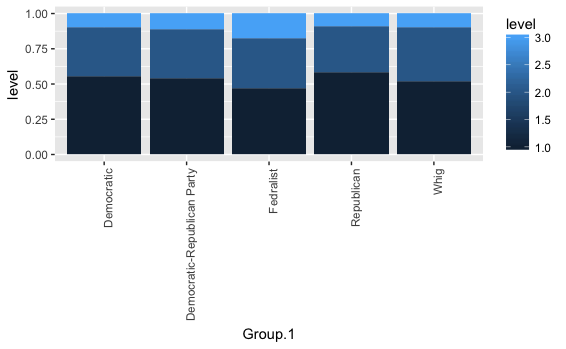

# Is Trump’s speaking manner following some trend?

I plot each president’s vocabulary distribution along the time line:

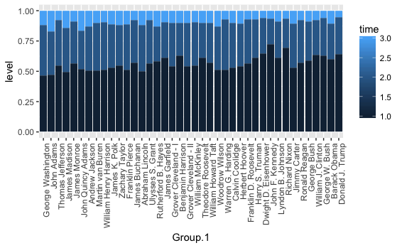

As suggested in the barplot, there is a slow increase in basic word use and decrease in advanced word use. Inaugural speeches mainly consist of basic words, and the portion of intermediate vocabulary remains relatively stable across time. In conclusion, the simplicity of Trump’s inaugural speech examplifies a trend in the political sphere. I then proceed to explain this trend by topic modeling.

# Topic modeling

For topic modeling, I run LDA for all the vocabulary in the speeches, which are grouped into 15 categories: “election”,“hope”,“defense”,“motivation”,“legislation”,“ideology”,“nation”,“citizenship”,“economy”,“service”,“gov-system”,“international”,“individual”,“market”,“workingfamily”

```
Discrepancy: Rowv is FALSE, while dendrogram is `both'. Omitting row dendogram.
```

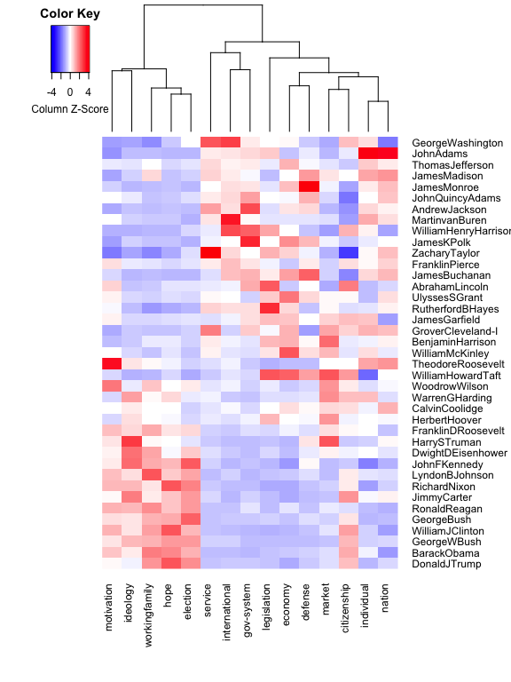

```r
heatmap.2(as.matrix(topic.summary[,topic.plot+1]),
          scale = "column", key=T,,keysize = 1,
          col = bluered(100),
          cexRow = 0.9, cexCol = 0.9, margins = c(8, 8),
          trace = "none", Rowv = NA, density.info = "none")
```

The heatmap shows a shift in topics. Before Roosevelt, most presidential speeches expounded on concrete policies and ideas such as legislation, govenment system and economy etc whereas the more recent presidential speech focused more on abstract ideologies, hope and motivation etc. Notice that a shift in topics could cause a change in the frequency of certain lists of vocabulary. For example topics like government service, system and economy might require more advanced words than those for the “hope” and “motivation”.

# Conclusion